# Risk Factor Analysis

## Outcome Variable

**Outcome Variable:** pers_wast

## Predictor Variables

**Intervention Variable:** parity

**Adjustment Set:**

unadjusted

## Stratifying Variables

The analysis was stratified on these variable(s):

- agecat
- studyid
- country

## Data Summary

| agecat | studyid | country | parity | pers_wast | n_cell | n |
| --- | --- | --- | --- | --- | --- | --- |
| 0-24 months | ki1000304b-SAS-CompFeed | INDIA | 1 | 0 | 378 | 1366 |
| 0-24 months | ki1000304b-SAS-CompFeed | INDIA | 1 | 1 | 30 | 1366 |
| 0-24 months | ki1000304b-SAS-CompFeed | INDIA | 2 | 0 | 291 | 1366 |
| 0-24 months | ki1000304b-SAS-CompFeed | INDIA | 2 | 1 | 27 | 1366 |
| 0-24 months | ki1000304b-SAS-CompFeed | INDIA | 3+ | 0 | 583 | 1366 |
| 0-24 months | ki1000304b-SAS-CompFeed | INDIA | 3+ | 1 | 57 | 1366 |
| 0-24 months | ki1000304b-SAS-FoodSuppl | INDIA | 1 | 0 | 62 | 373 |
| 0-24 months | ki1000304b-SAS-FoodSuppl | INDIA | 1 | 1 | 7 | 373 |
| 0-24 months | ki1000304b-SAS-FoodSuppl | INDIA | 2 | 0 | 76 | 373 |
| 0-24 months | ki1000304b-SAS-FoodSuppl | INDIA | 2 | 1 | 11 | 373 |
| 0-24 months | ki1000304b-SAS-FoodSuppl | INDIA | 3+ | 0 | 171 | 373 |
| 0-24 months | ki1000304b-SAS-FoodSuppl | INDIA | 3+ | 1 | 46 | 373 |
| 0-24 months | ki1017093b-PROVIDE | BANGLADESH | 1 | 0 | 237 | 640 |
| 0-24 months | ki1017093b-PROVIDE | BANGLADESH | 1 | 1 | 4 | 640 |
| 0-24 months | ki1017093b-PROVIDE | BANGLADESH | 2 | 0 | 223 | 640 |
| 0-24 months | ki1017093b-PROVIDE | BANGLADESH | 2 | 1 | 4 | 640 |
| 0-24 months | ki1017093b-PROVIDE | BANGLADESH | 3+ | 0 | 165 | 640 |
| 0-24 months | ki1017093b-PROVIDE | BANGLADESH | 3+ | 1 | 7 | 640 |
| 0-24 months | ki1066203-TanzaniaChild2 | TANZANIA, UNITED REPUBLIC OF | 1 | 0 | 710 | 2132 |
| 0-24 months | ki1066203-TanzaniaChild2 | TANZANIA, UNITED REPUBLIC OF | 1 | 1 | 18 | 2132 |
| 0-24 months | ki1066203-TanzaniaChild2 | TANZANIA, UNITED REPUBLIC OF | 2 | 0 | 683 | 2132 |
| 0-24 months | ki1066203-TanzaniaChild2 | TANZANIA, UNITED REPUBLIC OF | 2 | 1 | 20 | 2132 |
| 0-24 months | ki1066203-TanzaniaChild2 | TANZANIA, UNITED REPUBLIC OF | 3+ | 0 | 682 | 2132 |
| 0-24 months | ki1066203-TanzaniaChild2 | TANZANIA, UNITED REPUBLIC OF | 3+ | 1 | 19 | 2132 |
| 0-24 months | ki1101329-Keneba | GAMBIA | 1 | 0 | 220 | 1850 |
| 0-24 months | ki1101329-Keneba | GAMBIA | 1 | 1 | 9 | 1850 |
| 0-24 months | ki1101329-Keneba | GAMBIA | 2 | 0 | 190 | 1850 |
| 0-24 months | ki1101329-Keneba | GAMBIA | 2 | 1 | 9 | 1850 |
| 0-24 months | ki1101329-Keneba | GAMBIA | 3+ | 0 | 1350 | 1850 |
| 0-24 months | ki1101329-Keneba | GAMBIA | 3+ | 1 | 72 | 1850 |

[output cut: 114 more lines]

The following strata were considered:

- agecat: 0-24 months, studyid: ki1000304b-SAS-CompFeed, country: INDIA
- agecat: 0-24 months, studyid: ki1000304b-SAS-FoodSuppl, country: INDIA
- agecat: 0-24 months, studyid: ki1017093b-PROVIDE, country: BANGLADESH
- agecat: 0-24 months, studyid: ki1066203-TanzaniaChild2, country: TANZANIA, UNITED REPUBLIC OF
- agecat: 0-24 months, studyid: ki1101329-Keneba, country: GAMBIA
- agecat: 0-24 months, studyid: ki1113344-GMS-Nepal, country: NEPAL
- agecat: 0-24 months, studyid: ki1126311-ZVITAMBO, country: ZIMBABWE
- agecat: 0-24 months, studyid: ki1135781-COHORTS, country: GUATEMALA
- agecat: 0-24 months, studyid: ki1135781-COHORTS, country: INDIA
- agecat: 0-24 months, studyid: ki1135781-COHORTS, country: PHILIPPINES
- agecat: 0-24 months, studyid: kiGH5241-JiVitA-3, country: BANGLADESH
- agecat: 0-6 months, studyid: ki1017093b-PROVIDE, country: BANGLADESH
- agecat: 0-6 months, studyid: ki1066203-TanzaniaChild2, country: TANZANIA, UNITED REPUBLIC OF
- agecat: 0-6 months, studyid: ki1101329-Keneba, country: GAMBIA
- agecat: 0-6 months, studyid: ki1113344-GMS-Nepal, country: NEPAL
- agecat: 6-24 months, studyid: ki1000304b-SAS-CompFeed, country: INDIA
- agecat: 6-24 months, studyid: ki1000304b-SAS-FoodSuppl, country: INDIA
- agecat: 6-24 months, studyid: ki1017093b-PROVIDE, country: BANGLADESH
- agecat: 6-24 months, studyid: ki1066203-TanzaniaChild2, country: TANZANIA, UNITED REPUBLIC OF
- agecat: 6-24 months, studyid: ki1101329-Keneba, country: GAMBIA
- agecat: 6-24 months, studyid: ki1113344-GMS-Nepal, country: NEPAL
- agecat: 6-24 months, studyid: ki1126311-ZVITAMBO, country: ZIMBABWE
- agecat: 6-24 months, studyid: ki1135781-COHORTS, country: GUATEMALA
- agecat: 6-24 months, studyid: ki1135781-COHORTS, country: PHILIPPINES

### Dropped Strata

Some strata were dropped due to rare outcomes:

- agecat: 0-24 months, studyid: ki1017093b-PROVIDE, country: BANGLADESH
- agecat: 0-24 months, studyid: ki1135781-COHORTS, country: GUATEMALA
- agecat: 0-6 months, studyid: ki1017093b-PROVIDE, country: BANGLADESH
- agecat: 0-6 months, studyid: ki1101329-Keneba, country: GAMBIA
- agecat: 6-24 months, studyid: ki1135781-COHORTS, country: GUATEMALA

## Methods Detail

We’re interested in the causal parameters $E[Y_a]$ for all values of $a \in \mathcal{A}$. These parameters represent the mean outcome if, possibly contrary to fact, we intervened to set all units to have $A=a$. Under the randomization and positivity assumptions, these are identified by the statistical parameters $\psi_a=E_W[E_{Y|A,W}(Y|A=a,W)]$. In addition, we’re interested in the mean of $Y$, $E[Y]$ under no intervention (the observed mean). We will estimate these parameters by using SuperLearner to fit the relevant likelihood factors – $E_{Y|A,W}(Y|A=a,W)$ and $p(A=a|W)$, and then updating our likelihood fit using a joint TMLE.

For unadjusted analyses ($W=\{\}$), initial likelihoods were estimated using Lrnr_glm to estimate the simple $E(Y|A)$ and Lrnr_mean to estimate $p(A)$. For adjusted analyses, a small library containing Lrnr_glmnet, Lrnr_xgboost, and Lrnr_mean was used.

Having estimated these parameters, we will then use the delta method to estimate relative risks and attributable risks relative to a prespecified baseline level of $A$.

# Results Detail

## Results Plots

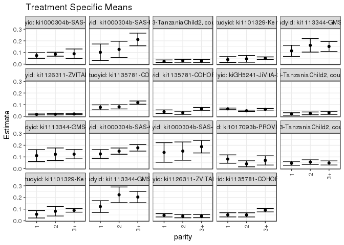

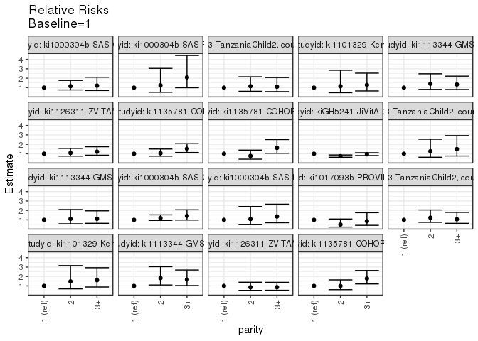

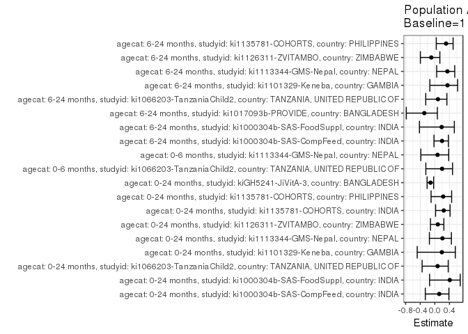

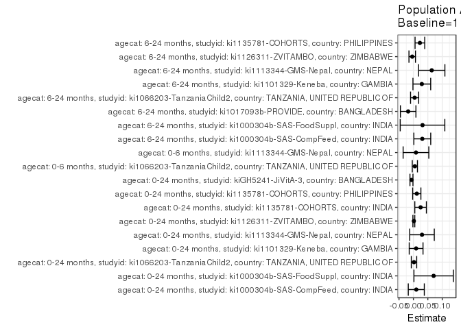

## Results Table

### Parameter: TSM

| agecat | studyid | country | intervention_level | baseline_level | estimate | ci_lower | ci_upper |
| --- | --- | --- | --- | --- | --- | --- | --- |
| 0-24 months | ki1000304b-SAS-CompFeed | INDIA | 1 | NA | 0.0735294 | 0.0491492 | 0.0979096 |
| 0-24 months | ki1000304b-SAS-CompFeed | INDIA | 2 | NA | 0.0849057 | 0.0680168 | 0.1017946 |
| 0-24 months | ki1000304b-SAS-CompFeed | INDIA | 3+ | NA | 0.0890625 | 0.0480466 | 0.1300784 |
| 0-24 months | ki1000304b-SAS-FoodSuppl | INDIA | 1 | NA | 0.1014493 | 0.0301143 | 0.1727842 |
| 0-24 months | ki1000304b-SAS-FoodSuppl | INDIA | 2 | NA | 0.1264368 | 0.0565081 | 0.1963655 |
| 0-24 months | ki1000304b-SAS-FoodSuppl | INDIA | 3+ | NA | 0.2119816 | 0.1575290 | 0.2664341 |
| 0-24 months | ki1066203-TanzaniaChild2 | TANZANIA, UNITED REPUBLIC OF | 1 | NA | 0.0247253 | 0.0134424 | 0.0360081 |
| 0-24 months | ki1066203-TanzaniaChild2 | TANZANIA, UNITED REPUBLIC OF | 2 | NA | 0.0284495 | 0.0161569 | 0.0407421 |
| 0-24 months | ki1066203-TanzaniaChild2 | TANZANIA, UNITED REPUBLIC OF | 3+ | NA | 0.0271041 | 0.0150803 | 0.0391279 |
| 0-24 months | ki1101329-Keneba | GAMBIA | 1 | NA | 0.0393013 | 0.0141277 | 0.0644749 |
| 0-24 months | ki1101329-Keneba | GAMBIA | 2 | NA | 0.0452261 | 0.0163470 | 0.0741053 |
| 0-24 months | ki1101329-Keneba | GAMBIA | 3+ | NA | 0.0506329 | 0.0392344 | 0.0620315 |
| 0-24 months | ki1113344-GMS-Nepal | NEPAL | 1 | NA | 0.1137725 | 0.0655723 | 0.1619726 |
| 0-24 months | ki1113344-GMS-Nepal | NEPAL | 2 | NA | 0.1612903 | 0.1033395 | 0.2192411 |
| 0-24 months | ki1113344-GMS-Nepal | NEPAL | 3+ | NA | 0.1518519 | 0.1090089 | 0.1946948 |
| 0-24 months | ki1126311-ZVITAMBO | ZIMBABWE | 1 | NA | 0.0164332 | 0.0123431 | 0.0205233 |
| 0-24 months | ki1126311-ZVITAMBO | ZIMBABWE | 2 | NA | 0.0177886 | 0.0129499 | 0.0226274 |
| 0-24 months | ki1126311-ZVITAMBO | ZIMBABWE | 3+ | NA | 0.0199782 | 0.0147511 | 0.0252053 |
| 0-24 months | ki1135781-COHORTS | INDIA | 1 | NA | 0.0771812 | 0.0557523 | 0.0986101 |
| 0-24 months | ki1135781-COHORTS | INDIA | 2 | NA | 0.0812918 | 0.0634153 | 0.0991683 |
| 0-24 months | ki1135781-COHORTS | INDIA | 3+ | NA | 0.1180390 | 0.1042405 | 0.1318376 |
| 0-24 months | ki1135781-COHORTS | PHILIPPINES | 1 | NA | 0.0395387 | 0.0240333 | 0.0550441 |
| 0-24 months | ki1135781-COHORTS | PHILIPPINES | 2 | NA | 0.0303030 | 0.0168830 | 0.0437230 |
| 0-24 months | ki1135781-COHORTS | PHILIPPINES | 3+ | NA | 0.0640457 | 0.0519597 | 0.0761316 |
| 0-24 months | kiGH5241-JiVitA-3 | BANGLADESH | 1 | NA | 0.0640576 | 0.0569144 | 0.0712008 |
| 0-24 months | kiGH5241-JiVitA-3 | BANGLADESH | 2 | NA | 0.0473907 | 0.0412529 | 0.0535285 |
| 0-24 months | kiGH5241-JiVitA-3 | BANGLADESH | 3+ | NA | 0.0604263 | 0.0534449 | 0.0674076 |
| 0-6 months | ki1066203-TanzaniaChild2 | TANZANIA, UNITED REPUBLIC OF | 1 | NA | 0.0201439 | 0.0096963 | 0.0305915 |
| 0-6 months | ki1066203-TanzaniaChild2 | TANZANIA, UNITED REPUBLIC OF | 2 | NA | 0.0254111 | 0.0134832 | 0.0373390 |
| 0-6 months | ki1066203-TanzaniaChild2 | TANZANIA, UNITED REPUBLIC OF | 3+ | NA | 0.0300300 | 0.0170650 | 0.0429951 |
| 0-6 months | ki1113344-GMS-Nepal | NEPAL | 1 | NA | 0.1111111 | 0.0597339 | 0.1624883 |
| 0-6 months | ki1113344-GMS-Nepal | NEPAL | 2 | NA | 0.1223022 | 0.0677852 | 0.1768191 |
| 0-6 months | ki1113344-GMS-Nepal | NEPAL | 3+ | NA | 0.1235521 | 0.0834389 | 0.1636653 |
| 6-24 months | ki1000304b-SAS-CompFeed | INDIA | 1 | NA | 0.1253561 | 0.0876019 | 0.1631103 |
| 6-24 months | ki1000304b-SAS-CompFeed | INDIA | 2 | NA | 0.1496350 | 0.1228184 | 0.1764517 |
| 6-24 months | ki1000304b-SAS-CompFeed | INDIA | 3+ | NA | 0.1778929 | 0.1499324 | 0.2058534 |
| 6-24 months | ki1000304b-SAS-FoodSuppl | INDIA | 1 | NA | 0.1384615 | 0.0543763 | 0.2225468 |
| 6-24 months | ki1000304b-SAS-FoodSuppl | INDIA | 2 | NA | 0.1500000 | 0.0716417 | 0.2283583 |
| 6-24 months | ki1000304b-SAS-FoodSuppl | INDIA | 3+ | NA | 0.1881188 | 0.1341477 | 0.2420899 |
| 6-24 months | ki1017093b-PROVIDE | BANGLADESH | 1 | NA | 0.0814480 | 0.0453564 | 0.1175395 |
| 6-24 months | ki1017093b-PROVIDE | BANGLADESH | 2 | NA | 0.0405405 | 0.0145754 | 0.0665057 |
| 6-24 months | ki1017093b-PROVIDE | BANGLADESH | 3+ | NA | 0.0696203 | 0.0299030 | 0.1093375 |
| 6-24 months | ki1066203-TanzaniaChild2 | TANZANIA, UNITED REPUBLIC OF | 1 | NA | 0.0452962 | 0.0282790 | 0.0623133 |
| 6-24 months | ki1066203-TanzaniaChild2 | TANZANIA, UNITED REPUBLIC OF | 2 | NA | 0.0555556 | 0.0362300 | 0.0748811 |
| 6-24 months | ki1066203-TanzaniaChild2 | TANZANIA, UNITED REPUBLIC OF | 3+ | NA | 0.0479574 | 0.0303019 | 0.0656128 |
| 6-24 months | ki1101329-Keneba | GAMBIA | 1 | NA | 0.0552764 | 0.0235173 | 0.0870355 |
| 6-24 months | ki1101329-Keneba | GAMBIA | 2 | NA | 0.0813953 | 0.0405189 | 0.1222718 |
| 6-24 months | ki1101329-Keneba | GAMBIA | 3+ | NA | 0.0890511 | 0.0739649 | 0.1041373 |
| 6-24 months | ki1113344-GMS-Nepal | NEPAL | 1 | NA | 0.1219512 | 0.0718261 | 0.1720763 |
| 6-24 months | ki1113344-GMS-Nepal | NEPAL | 2 | NA | 0.2229730 | 0.1558551 | 0.2900908 |
| 6-24 months | ki1113344-GMS-Nepal | NEPAL | 3+ | NA | 0.2037736 | 0.1552342 | 0.2523129 |
| 6-24 months | ki1126311-ZVITAMBO | ZIMBABWE | 1 | NA | 0.0468557 | 0.0323080 | 0.0614035 |
| 6-24 months | ki1126311-ZVITAMBO | ZIMBABWE | 2 | NA | 0.0401189 | 0.0252896 | 0.0549482 |
| 6-24 months | ki1126311-ZVITAMBO | ZIMBABWE | 3+ | NA | 0.0404858 | 0.0262915 | 0.0546801 |
| 6-24 months | ki1135781-COHORTS | PHILIPPINES | 1 | NA | 0.0506993 | 0.0327174 | 0.0686812 |
| 6-24 months | ki1135781-COHORTS | PHILIPPINES | 2 | NA | 0.0503472 | 0.0324869 | 0.0682075 |
| 6-24 months | ki1135781-COHORTS | PHILIPPINES | 3+ | NA | 0.0905433 | 0.0759749 | 0.1051116 |

### Parameter: E(Y)

| agecat | studyid | country | intervention_level | baseline_level | estimate | ci_lower | ci_upper |
| --- | --- | --- | --- | --- | --- | --- | --- |
| 0-24 months | ki1000304b-SAS-CompFeed | INDIA | NA | NA | 0.0834553 | 0.0601989 | 0.1067118 |
| 0-24 months | ki1000304b-SAS-FoodSuppl | INDIA | NA | NA | 0.1715818 | 0.1332696 | 0.2098940 |
| 0-24 months | ki1066203-TanzaniaChild2 | TANZANIA, UNITED REPUBLIC OF | NA | NA | 0.0267355 | 0.0198866 | 0.0335843 |
| 0-24 months | ki1101329-Keneba | GAMBIA | NA | NA | 0.0486486 | 0.0388428 | 0.0584545 |
| 0-24 months | ki1113344-GMS-Nepal | NEPAL | NA | NA | 0.1435811 | 0.1153098 | 0.1718524 |
| 0-24 months | ki1126311-ZVITAMBO | ZIMBABWE | NA | NA | 0.0178954 | 0.0152055 | 0.0205853 |
| 0-24 months | ki1135781-COHORTS | INDIA | NA | NA | 0.1020862 | 0.0921879 | 0.1119845 |
| 0-24 months | ki1135781-COHORTS | PHILIPPINES | NA | NA | 0.0512273 | 0.0430760 | 0.0593786 |
| 0-24 months | kiGH5241-JiVitA-3 | BANGLADESH | NA | NA | 0.0572358 | 0.0531429 | 0.0613287 |
| 0-6 months | ki1066203-TanzaniaChild2 | TANZANIA, UNITED REPUBLIC OF | NA | NA | 0.0251232 | 0.0183136 | 0.0319327 |
| 0-6 months | ki1113344-GMS-Nepal | NEPAL | NA | NA | 0.1199262 | 0.0925504 | 0.1473020 |
| 6-24 months | ki1000304b-SAS-CompFeed | INDIA | NA | NA | 0.1561462 | 0.1410608 | 0.1712315 |
| 6-24 months | ki1000304b-SAS-FoodSuppl | INDIA | NA | NA | 0.1700288 | 0.1304464 | 0.2096113 |
| 6-24 months | ki1017093b-PROVIDE | BANGLADESH | NA | NA | 0.0632280 | 0.0437545 | 0.0827015 |
| 6-24 months | ki1066203-TanzaniaChild2 | TANZANIA, UNITED REPUBLIC OF | NA | NA | 0.0494931 | 0.0391092 | 0.0598771 |
| 6-24 months | ki1101329-Keneba | GAMBIA | NA | NA | 0.0844342 | 0.0713702 | 0.0974983 |
| 6-24 months | ki1113344-GMS-Nepal | NEPAL | NA | NA | 0.1854419 | 0.1537023 | 0.2171816 |
| 6-24 months | ki1126311-ZVITAMBO | ZIMBABWE | NA | NA | 0.0426966 | 0.0342942 | 0.0510990 |
| 6-24 months | ki1135781-COHORTS | PHILIPPINES | NA | NA | 0.0731338 | 0.0631985 | 0.0830690 |

### Parameter: RR

| agecat | studyid | country | intervention_level | baseline_level | estimate | ci_lower | ci_upper |
| --- | --- | --- | --- | --- | --- | --- | --- |
| 0-24 months | ki1000304b-SAS-CompFeed | INDIA | 1 | 1 | 1.0000000 | 1.0000000 | 1.0000000 |
| 0-24 months | ki1000304b-SAS-CompFeed | INDIA | 2 | 1 | 1.1547170 | 0.7565289 | 1.7624855 |
| 0-24 months | ki1000304b-SAS-CompFeed | INDIA | 3+ | 1 | 1.2112500 | 0.6974280 | 2.1036243 |
| 0-24 months | ki1000304b-SAS-FoodSuppl | INDIA | 1 | 1 | 1.0000000 | 1.0000000 | 1.0000000 |
| 0-24 months | ki1000304b-SAS-FoodSuppl | INDIA | 2 | 1 | 1.2463054 | 0.5094502 | 3.0489281 |
| 0-24 months | ki1000304b-SAS-FoodSuppl | INDIA | 3+ | 1 | 2.0895326 | 0.9883986 | 4.4173943 |
| 0-24 months | ki1066203-TanzaniaChild2 | TANZANIA, UNITED REPUBLIC OF | 1 | 1 | 1.0000000 | 1.0000000 | 1.0000000 |
| 0-24 months | ki1066203-TanzaniaChild2 | TANZANIA, UNITED REPUBLIC OF | 2 | 1 | 1.1506243 | 0.6137724 | 2.1570475 |
| 0-24 months | ki1066203-TanzaniaChild2 | TANZANIA, UNITED REPUBLIC OF | 3+ | 1 | 1.0962118 | 0.5800975 | 2.0715142 |
| 0-24 months | ki1101329-Keneba | GAMBIA | 1 | 1 | 1.0000000 | 1.0000000 | 1.0000000 |
| 0-24 months | ki1101329-Keneba | GAMBIA | 2 | 1 | 1.1507536 | 0.4657865 | 2.8430063 |
| 0-24 months | ki1101329-Keneba | GAMBIA | 3+ | 1 | 1.2883261 | 0.6533823 | 2.5402955 |
| 0-24 months | ki1113344-GMS-Nepal | NEPAL | 1 | 1 | 1.0000000 | 1.0000000 | 1.0000000 |
| 0-24 months | ki1113344-GMS-Nepal | NEPAL | 2 | 1 | 1.4176570 | 0.8134344 | 2.4706989 |
| 0-24 months | ki1113344-GMS-Nepal | NEPAL | 3+ | 1 | 1.3346979 | 0.8022801 | 2.2204443 |
| 0-24 months | ki1126311-ZVITAMBO | ZIMBABWE | 1 | 1 | 1.0000000 | 1.0000000 | 1.0000000 |
| 0-24 months | ki1126311-ZVITAMBO | ZIMBABWE | 2 | 1 | 1.0824818 | 0.7486825 | 1.5651053 |
| 0-24 months | ki1126311-ZVITAMBO | ZIMBABWE | 3+ | 1 | 1.2157229 | 0.8472369 | 1.7444733 |
| 0-24 months | ki1135781-COHORTS | INDIA | 1 | 1 | 1.0000000 | 1.0000000 | 1.0000000 |
| 0-24 months | ki1135781-COHORTS | INDIA | 2 | 1 | 1.0532584 | 0.7391217 | 1.5009075 |
| 0-24 months | ki1135781-COHORTS | INDIA | 3+ | 1 | 1.5293752 | 1.1315744 | 2.0670215 |
| 0-24 months | ki1135781-COHORTS | PHILIPPINES | 1 | 1 | 1.0000000 | 1.0000000 | 1.0000000 |
| 0-24 months | ki1135781-COHORTS | PHILIPPINES | 2 | 1 | 0.7664141 | 0.4241932 | 1.3847242 |
| 0-24 months | ki1135781-COHORTS | PHILIPPINES | 3+ | 1 | 1.6198214 | 1.0482449 | 2.5030614 |
| 0-24 months | kiGH5241-JiVitA-3 | BANGLADESH | 1 | 1 | 1.0000000 | 1.0000000 | 1.0000000 |
| 0-24 months | kiGH5241-JiVitA-3 | BANGLADESH | 2 | 1 | 0.7398150 | 0.6296322 | 0.8692791 |
| 0-24 months | kiGH5241-JiVitA-3 | BANGLADESH | 3+ | 1 | 0.9433122 | 0.8042238 | 1.1064554 |
| 0-6 months | ki1066203-TanzaniaChild2 | TANZANIA, UNITED REPUBLIC OF | 1 | 1 | 1.0000000 | 1.0000000 | 1.0000000 |
| 0-6 months | ki1066203-TanzaniaChild2 | TANZANIA, UNITED REPUBLIC OF | 2 | 1 | 1.2614777 | 0.6267314 | 2.5390878 |
| 0-6 months | ki1066203-TanzaniaChild2 | TANZANIA, UNITED REPUBLIC OF | 3+ | 1 | 1.4907765 | 0.7591695 | 2.9274287 |
| 0-6 months | ki1113344-GMS-Nepal | NEPAL | 1 | 1 | 1.0000000 | 1.0000000 | 1.0000000 |
| 0-6 months | ki1113344-GMS-Nepal | NEPAL | 2 | 1 | 1.1007194 | 0.5790866 | 2.0922316 |
| 0-6 months | ki1113344-GMS-Nepal | NEPAL | 3+ | 1 | 1.1119691 | 0.6320034 | 1.9564378 |
| 6-24 months | ki1000304b-SAS-CompFeed | INDIA | 1 | 1 | 1.0000000 | 1.0000000 | 1.0000000 |
| 6-24 months | ki1000304b-SAS-CompFeed | INDIA | 2 | 1 | 1.1936795 | 0.9331185 | 1.5269987 |
| 6-24 months | ki1000304b-SAS-CompFeed | INDIA | 3+ | 1 | 1.4191003 | 0.9755238 | 2.0643739 |
| 6-24 months | ki1000304b-SAS-FoodSuppl | INDIA | 1 | 1 | 1.0000000 | 1.0000000 | 1.0000000 |
| 6-24 months | ki1000304b-SAS-FoodSuppl | INDIA | 2 | 1 | 1.0833333 | 0.4862619 | 2.4135368 |
| 6-24 months | ki1000304b-SAS-FoodSuppl | INDIA | 3+ | 1 | 1.3586359 | 0.6940848 | 2.6594608 |
| 6-24 months | ki1017093b-PROVIDE | BANGLADESH | 1 | 1 | 1.0000000 | 1.0000000 | 1.0000000 |
| 6-24 months | ki1017093b-PROVIDE | BANGLADESH | 2 | 1 | 0.4977478 | 0.2284392 | 1.0845465 |
| 6-24 months | ki1017093b-PROVIDE | BANGLADESH | 3+ | 1 | 0.8547820 | 0.4150843 | 1.7602503 |
| 6-24 months | ki1066203-TanzaniaChild2 | TANZANIA, UNITED REPUBLIC OF | 1 | 1 | 1.0000000 | 1.0000000 | 1.0000000 |
| 6-24 months | ki1066203-TanzaniaChild2 | TANZANIA, UNITED REPUBLIC OF | 2 | 1 | 1.2264957 | 0.7350315 | 2.0465677 |
| 6-24 months | ki1066203-TanzaniaChild2 | TANZANIA, UNITED REPUBLIC OF | 3+ | 1 | 1.0587512 | 0.6256851 | 1.7915626 |
| 6-24 months | ki1101329-Keneba | GAMBIA | 1 | 1 | 1.0000000 | 1.0000000 | 1.0000000 |
| 6-24 months | ki1101329-Keneba | GAMBIA | 2 | 1 | 1.4725159 | 0.6865199 | 3.1583976 |
| 6-24 months | ki1101329-Keneba | GAMBIA | 3+ | 1 | 1.6110153 | 0.8850225 | 2.9325473 |
| 6-24 months | ki1113344-GMS-Nepal | NEPAL | 1 | 1 | 1.0000000 | 1.0000000 | 1.0000000 |
| 6-24 months | ki1113344-GMS-Nepal | NEPAL | 2 | 1 | 1.8283784 | 1.0985242 | 3.0431440 |
| 6-24 months | ki1113344-GMS-Nepal | NEPAL | 3+ | 1 | 1.6709434 | 1.0390717 | 2.6870636 |
| 6-24 months | ki1126311-ZVITAMBO | ZIMBABWE | 1 | 1 | 1.0000000 | 1.0000000 | 1.0000000 |
| 6-24 months | ki1126311-ZVITAMBO | ZIMBABWE | 2 | 1 | 0.8562212 | 0.5283715 | 1.3874985 |
| 6-24 months | ki1126311-ZVITAMBO | ZIMBABWE | 3+ | 1 | 0.8640528 | 0.5409466 | 1.3801497 |
| 6-24 months | ki1135781-COHORTS | PHILIPPINES | 1 | 1 | 1.0000000 | 1.0000000 | 1.0000000 |
| 6-24 months | ki1135781-COHORTS | PHILIPPINES | 2 | 1 | 0.9930556 | 0.6013342 | 1.6399523 |
| 6-24 months | ki1135781-COHORTS | PHILIPPINES | 3+ | 1 | 1.7858877 | 1.2097922 | 2.6363164 |

### Parameter: PAR

| agecat | studyid | country | intervention_level | baseline_level | estimate | ci_lower | ci_upper |
| --- | --- | --- | --- | --- | --- | --- | --- |
| 0-24 months | ki1000304b-SAS-CompFeed | INDIA | 1 | NA | 0.0099259 | -0.0179202 | 0.0377721 |
| 0-24 months | ki1000304b-SAS-FoodSuppl | INDIA | 1 | NA | 0.0701325 | 0.0017671 | 0.1384979 |
| 0-24 months | ki1066203-TanzaniaChild2 | TANZANIA, UNITED REPUBLIC OF | 1 | NA | 0.0020102 | -0.0073317 | 0.0113521 |
| 0-24 months | ki1101329-Keneba | GAMBIA | 1 | NA | 0.0093473 | -0.0145896 | 0.0332843 |
| 0-24 months | ki1113344-GMS-Nepal | NEPAL | 1 | NA | 0.0298086 | -0.0127562 | 0.0723735 |
| 0-24 months | ki1126311-ZVITAMBO | ZIMBABWE | 1 | NA | 0.0014622 | -0.0018021 | 0.0047265 |
| 0-24 months | ki1135781-COHORTS | INDIA | 1 | NA | 0.0249050 | 0.0047825 | 0.0450276 |
| 0-24 months | ki1135781-COHORTS | PHILIPPINES | 1 | NA | 0.0116886 | -0.0025603 | 0.0259375 |
| 0-24 months | kiGH5241-JiVitA-3 | BANGLADESH | 1 | NA | -0.0068217 | -0.0120132 | -0.0016302 |
| 0-6 months | ki1066203-TanzaniaChild2 | TANZANIA, UNITED REPUBLIC OF | 1 | NA | 0.0049793 | -0.0040086 | 0.0139672 |
| 0-6 months | ki1113344-GMS-Nepal | NEPAL | 1 | NA | 0.0088151 | -0.0357545 | 0.0533847 |
| 6-24 months | ki1000304b-SAS-CompFeed | INDIA | 1 | NA | 0.0307901 | 0.0014827 | 0.0600974 |
| 6-24 months | ki1000304b-SAS-FoodSuppl | INDIA | 1 | NA | 0.0315673 | -0.0458167 | 0.1089512 |
| 6-24 months | ki1017093b-PROVIDE | BANGLADESH | 1 | NA | -0.0182200 | -0.0451241 | 0.0086841 |
| 6-24 months | ki1066203-TanzaniaChild2 | TANZANIA, UNITED REPUBLIC OF | 1 | NA | 0.0041970 | -0.0099159 | 0.0183098 |
| 6-24 months | ki1101329-Keneba | GAMBIA | 1 | NA | 0.0291579 | -0.0016436 | 0.0599593 |
| 6-24 months | ki1113344-GMS-Nepal | NEPAL | 1 | NA | 0.0634907 | 0.0177560 | 0.1092255 |
| 6-24 months | ki1126311-ZVITAMBO | ZIMBABWE | 1 | NA | -0.0041591 | -0.0154709 | 0.0071527 |
| 6-24 months | ki1135781-COHORTS | PHILIPPINES | 1 | NA | 0.0224345 | 0.0056450 | 0.0392239 |

### Parameter: PAF

| agecat | studyid | country | intervention_level | baseline_level | estimate | ci_lower | ci_upper |
| --- | --- | --- | --- | --- | --- | --- | --- |
| 0-24 months | ki1000304b-SAS-CompFeed | INDIA | 1 | NA | 0.1189370 | -0.2617197 | 0.3847509 |
| 0-24 months | ki1000304b-SAS-FoodSuppl | INDIA | 1 | NA | 0.4087409 | -0.1444251 | 0.6945302 |
| 0-24 months | ki1066203-TanzaniaChild2 | TANZANIA, UNITED REPUBLIC OF | 1 | NA | 0.0751880 | -0.3486669 | 0.3658350 |
| 0-24 months | ki1101329-Keneba | GAMBIA | 1 | NA | 0.1921396 | -0.4828459 | 0.5598744 |
| 0-24 months | ki1113344-GMS-Nepal | NEPAL | 1 | NA | 0.2076083 | -0.1488967 | 0.4534891 |
| 0-24 months | ki1126311-ZVITAMBO | ZIMBABWE | 1 | NA | 0.0817094 | -0.1195925 | 0.2468174 |
| 0-24 months | ki1135781-COHORTS | INDIA | 1 | NA | 0.2439606 | 0.0202944 | 0.4165640 |
| 0-24 months | ki1135781-COHORTS | PHILIPPINES | 1 | NA | 0.2281713 | -0.1035805 | 0.4601939 |
| 0-24 months | kiGH5241-JiVitA-3 | BANGLADESH | 1 | NA | -0.1191863 | -0.2125026 | -0.0330519 |
| 0-6 months | ki1066203-TanzaniaChild2 | TANZANIA, UNITED REPUBLIC OF | 1 | NA | 0.1981944 | -0.2466347 | 0.4842978 |
| 0-6 months | ki1113344-GMS-Nepal | NEPAL | 1 | NA | 0.0735043 | -0.3833037 | 0.3794607 |
| 6-24 months | ki1000304b-SAS-CompFeed | INDIA | 1 | NA | 0.1971874 | -0.0245364 | 0.3709271 |
| 6-24 months | ki1000304b-SAS-FoodSuppl | INDIA | 1 | NA | 0.1856584 | -0.4216626 | 0.5335375 |
| 6-24 months | ki1017093b-PROVIDE | BANGLADESH | 1 | NA | -0.2881638 | -0.7816690 | 0.0686452 |
| 6-24 months | ki1066203-TanzaniaChild2 | TANZANIA, UNITED REPUBLIC OF | 1 | NA | 0.0847991 | -0.2490808 | 0.3294328 |
| 6-24 months | ki1101329-Keneba | GAMBIA | 1 | NA | 0.3453321 | -0.1369159 | 0.6230240 |
| 6-24 months | ki1113344-GMS-Nepal | NEPAL | 1 | NA | 0.3423752 | 0.0502792 | 0.5446342 |
| 6-24 months | ki1126311-ZVITAMBO | ZIMBABWE | 1 | NA | -0.0974106 | -0.3962632 | 0.1374763 |
| 6-24 months | ki1135781-COHORTS | PHILIPPINES | 1 | NA | 0.3067593 | 0.0393215 | 0.4997466 |